# exam_1.Rmd

Hamaad Mehal

2/22/2020

# Question 1

1. The highest emissions are from the country China.
2. The number of countries that have neither ratified nor approved of the treaty is 9. (Acceptance and accession do not count as approval).
3. The longest number of days between signature and ratification (for a country that has successfully ratified) is 1384 days.
4. The number of ratifying countries whose name ends with “stan” is 7.
5. In 1960, the country with the highest emissions was Luxembourg.
6. The average emissions in 2000 was 4.5836466 metric tons per capita.

# Question 2

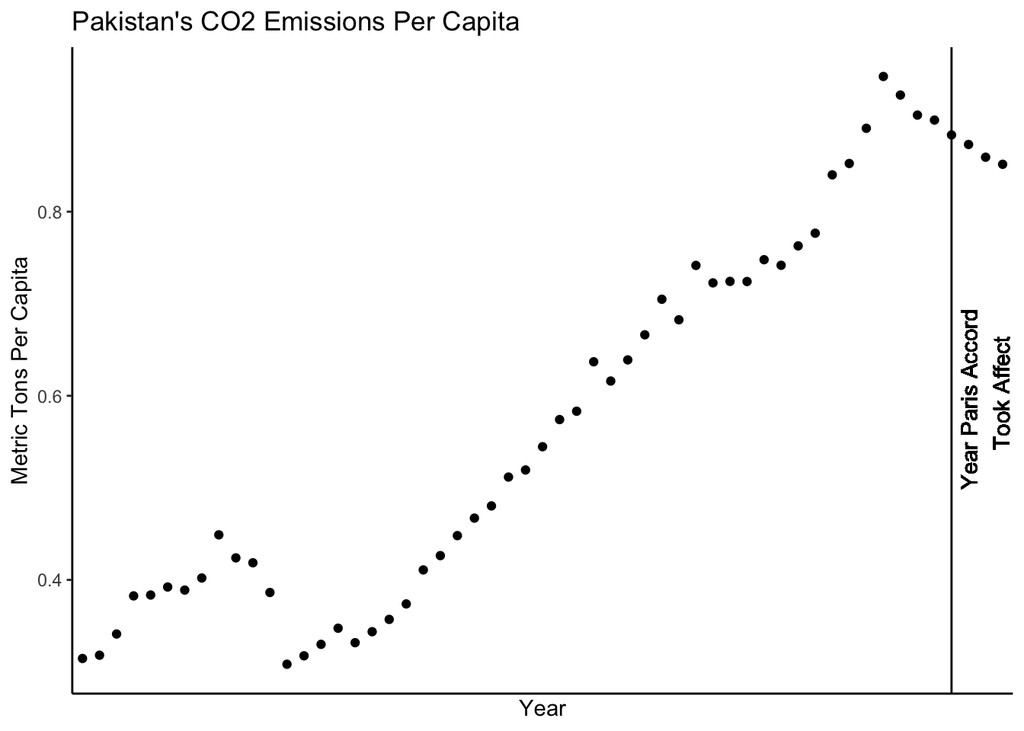

# Question 3

Monetary Effects on Emissions

| Country Name | Treatment | Control | Potential Outcomes Under Control | Potential Outcomes Under Treatment |
| --- | --- | --- | --- | --- |
| Afghanistan | 1 | 0 | ? | 19328 |
| Albania | 1 | 0 | ? | 6717 |
| Algeria | 1 | 0 | ? | 111023 |
| Andorra | 1 | 0 | ? | 522 |
| Antigua and Barbuda | 1 | 0 | ? | 598 |
| Argentina | 1 | 0 | ? | 332499 |
| Armenia | 1 | 0 | ? | 7464 |
| Australia | 1 | 0 | ? | 541924 |
| Austria | 1 | 0 | ? | 79599 |
| Azerbaijan | 1 | 0 | ? | 48209 |
| Bahamas | 0 | 1 | 688 | ? |
| Bahrain | 0 | 1 | 22373 | ? |
| Bangladesh | 0 | 1 | 99442 | ? |
| Barbados | 0 | 1 | 4056 | ? |
| Belgium | 0 | 1 | 119424 | ? |
| Belize | 0 | 1 | 1133 | ? |
| Benin | 0 | 1 | 6251 | ? |
| Bhutan | 0 | 1 | 1556 | ? |
| Bolivia (Plurinational State of) | 0 | 1 | 43665 | ? |
| Bosnia and Herzegovina | 0 | 1 | 31095 | ? |
| Botswana | 0 | 1 | 6140 | ? |
| Brazil | 0 | 1 | 923544 | ? |
| Brunei Darussalam | 0 | 1 | NA | ? |
| Bulgaria | 0 | 1 | 55893 | ? |
| Burkina Faso | 0 | 1 | 21593 | ? |
| Burundi | 0 | 1 | 26474 | ? |
| Cabo Verde | 0 | 1 | 448 | ? |
| Cambodia | 0 | 1 | 12763 | ? |
| Cameroon | 0 | 1 | 165725 | ? |
| Canada | 0 | 1 | 726051 | ? |

[output cut: 147 more lines]

The causal effect I am trying to measure is the effect that giving a billion dollars will have on the carbon emissions of a country that ratified the Paris treaty. The assignment mechanism being used is giving a billion dollars (the treatment group) to countries whose names start with a vowel amongst those nations that ratified the treaty. I do not think it’s random enough only because I do not know the frequency of nations that start with vowels amongst those that ratified the treaty, and there may be confounding factors in this method (i.e. nations in a certain region all have similar name beginning due to factors such as language, so this method doesn’t take into account this while filtering for randomness). There are question marks in half of the table because there is no way to measure the emissions of a nation that is not the other group as that relies on an a metric that did not occur and is thus a counterfactual. Because we have no actual observances in the other group, we cannot put data there as we do not know counterfactual emission levels. Thus, that data is left as question marks.